# Netflix Dataset Analysis

Abel

2025-01-17

[figure not shown]

## Introduction

**Introduction**

Netflix has revolutionized the entertainment industry, providing a diverse library of movies and TV shows for audiences worldwide. In this project, we analyze the Netflix dataset to explore trends, patterns, and insights related to content distribution, production years, and global reach.

#### **The Dataset inculdes information on**:

- Content type (Movies or TV Shows)
- Title, genre, and director
- Country of origin
- Release year and date added to Netflix
- Duration and rating

#### **Our analysis will focus on**:

1. Cleaning and preprocessing the data.
2. Exploring key trends in Netflix’s content library.
3. Visualizing insights using graphs and charts.
4. Drawing meaningful conclusions for stakeholders.

## Data Life Cycle

**Data Collection:**

**Source**: Netflix dataset containing information about movies and TV shows, such as type, title, director, country, release year, and ratings.

**Data Cleaning and Pre-Processing:**

- Removed unnecessary whitespaces and converted columns like date_added and release_year to appropriate formats.
- Extracted duration values and types into separate columns (duration_value, duration_type).
- Replaced empty strings in text fields with NA.
- Selected relevant columns for analysis.

**Data Transformation:**

- Filtered, grouped, and aggregated data to create meaningful insights, such as content distribution by type, country, and category.
- Expanded multi-value fields (e.g., listed_in) into separate rows for better analysis of categories and genres.

**Data Analysis and Visualization:**

- Performed statistical summaries and visualizations, including bar charts, scatter plots, line graphs, and heatmaps to uncover patterns and trends.
- Key focus areas: content type distribution, top countries in production, content added over time, and rating trends

## Visualizations

### **Content Analysis**

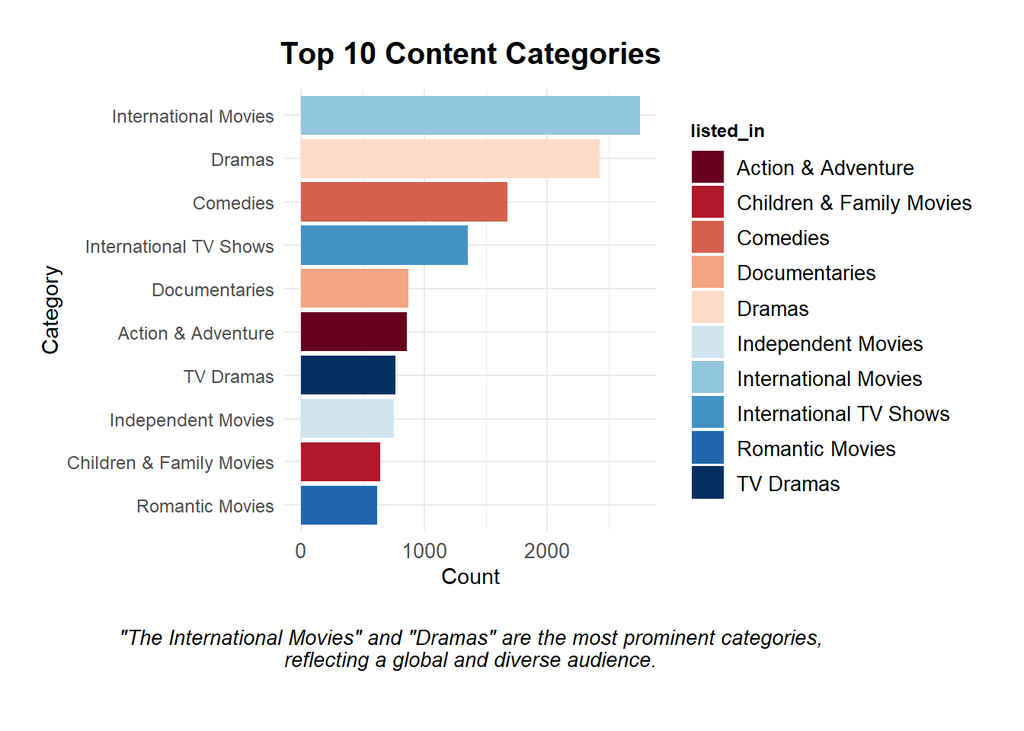

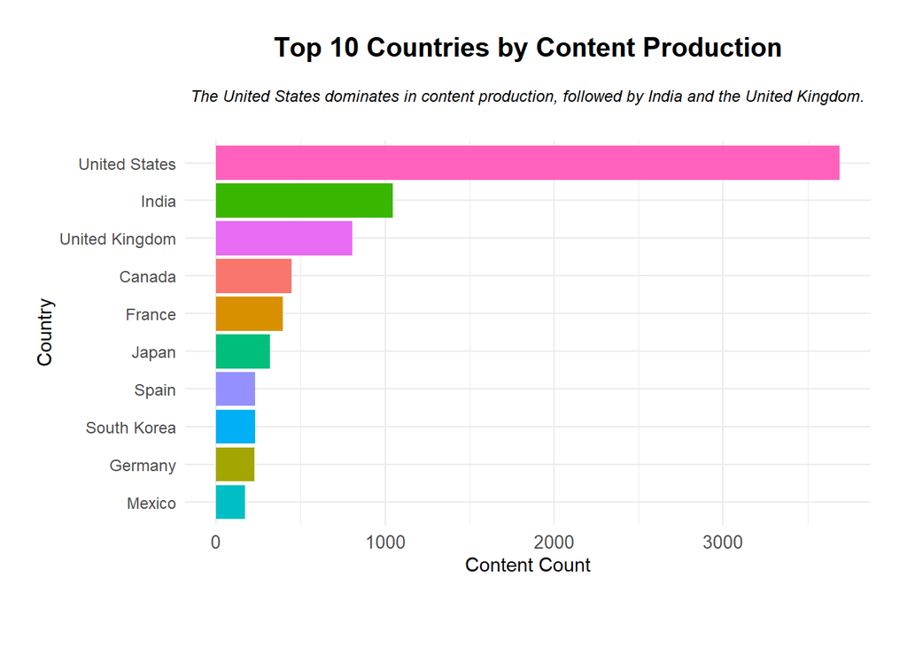

[figure not shown]

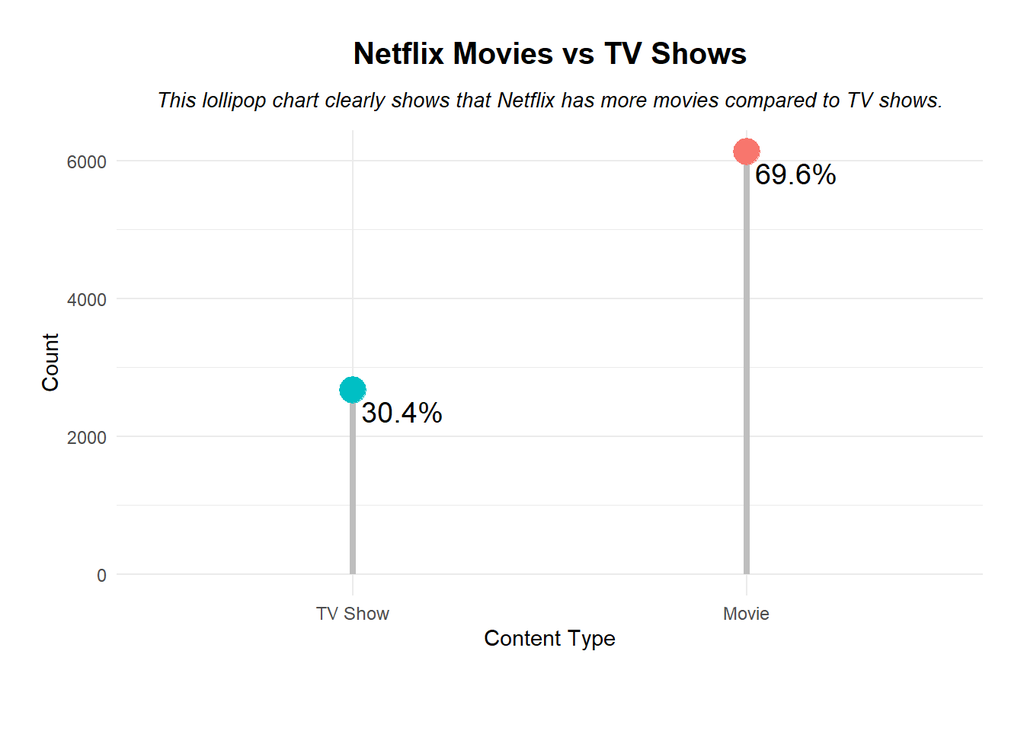

### **Netflix Content Trends**

[figure not shown]

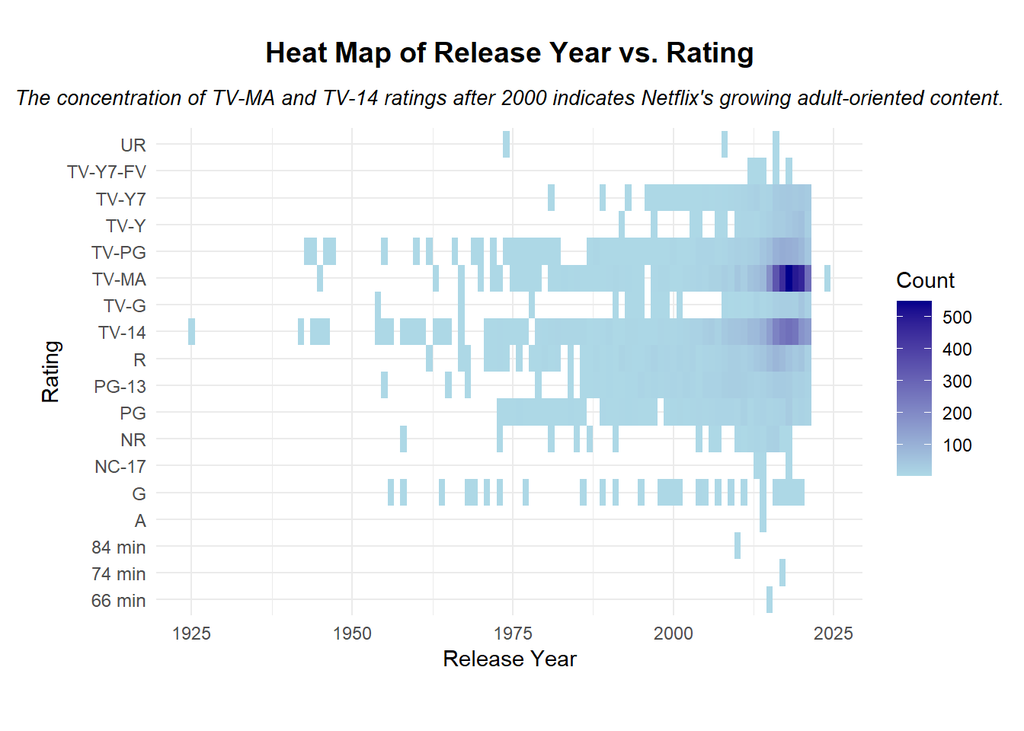

[figure not shown]

## Tables

| title | type | country | listed_in | date_added | release_year |
| --- | --- | --- | --- | --- | --- |
| Parasyte: The Grey | TV Show | South Korea | Sci-fi, Horror, Action | 2024-04-05 | 2024 |
| Serena | Movie | United States | Drama, Romance, Thriller | 2024-04-05 | 2014 |
| Dick Johnson Is Dead | Movie | United States | Documentaries | 2021-09-25 | 2020 |
| Blood & Water | TV Show | South Africa | International TV Shows, TV Dramas, TV Mysteries | 2021-09-24 | 2021 |
| Ganglands | TV Show | NA | Crime TV Shows, International TV Shows, TV Action & Adventure | 2021-09-24 | 2021 |
| Jailbirds New Orleans | TV Show | NA | Docuseries, Reality TV | 2021-09-24 | 2021 |
| Kota Factory | TV Show | India | International TV Shows, Romantic TV Shows, TV Comedies | 2021-09-24 | 2021 |
| Midnight Mass | TV Show | NA | TV Dramas, TV Horror, TV Mysteries | 2021-09-24 | 2021 |

Distribution of Content by Rating (with Total Count): TV-MA and TV-14 ratings dominate Netflix’s library, aligning with their focus on adult and young adult content.

| rating | Content_Count |
| --- | --- |
| TV-MA | 3208 |
| TV-14 | 2160 |
| TV-PG | 863 |
| R | 799 |
| PG-13 | 490 |
| TV-Y7 | 334 |
| TV-Y | 307 |
| PG | 287 |
| TV-G | 220 |
| NR | 80 |
| G | 41 |
| TV-Y7-FV | 6 |
| NA | 4 |
| NC-17 | 3 |
| UR | 3 |
| 66 min | 1 |
| 74 min | 1 |
| 84 min | 1 |
| A | 1 |
| Total | 8809 |

## Recommendations

**Recommendations**

- Expand Regional Content: Increase content from underrepresented countries to attract a more diverse global audience.
- Broaden Genre Offerings: Invest in underserved genres to appeal to niche audiences and differentiate from competitors.
- Analyze Viewer Engagement: Use viewer analytics to prioritize content types and ratings with the highest engagement.

**References**

[Exploring the Depths of Netflix;A Comprehensive Dataset of Movies and TV Shows](https://www.kaggle.com/datasets/rahulvyasm/netflix-movies-and-tv-shows)